# NHL: Conner McDavid Predictions

# Visualizing the Data

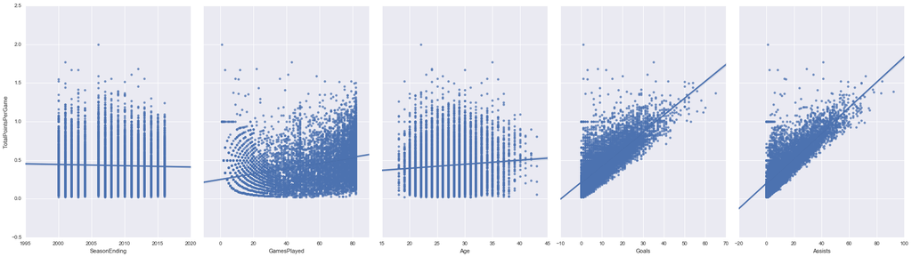

```python
sns.pairplot(df, x_vars=['SeasonEnding','GamesPlayed','Age','Goals', 'Assists'], y_vars=['TotalPointsPerGame'], size=7, aspect=0.7, kind='reg')
```

Visualizing the data and seeing if there are any clear relationships. As expected there is a linear relationship between goals and assists to total points per game, since points in hockey are a combination of goals and assists. Missing data from 2005. It looks like there is a quadratic relationship between age and TPPG, but another visualization should confirm this. Missing data from 2004-2005 season since the NHL had the lockout that year.

We can confirm correlation with TPPG with a regression line through the data. Goals and assists are positively correlated with TTPG seen by the high slope of the regression line. Age and Games played are only slightly correlated.

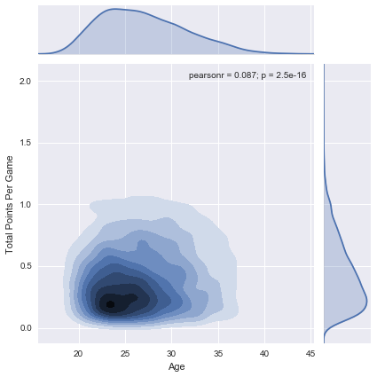

```python
g= sns.jointplot(data=df, x= 'Age', y='TotalPointsPerGame', kind="kde")
g.ax_joint.collections[0].set_alpha(0)
g.set_axis_labels("Age", "Total Points Per Game");
```

We can see here there is definitely more younger players over the years. Mainly between 21 to 27. Average players peak around 23-24 years old, but under 0.5 TPPG.

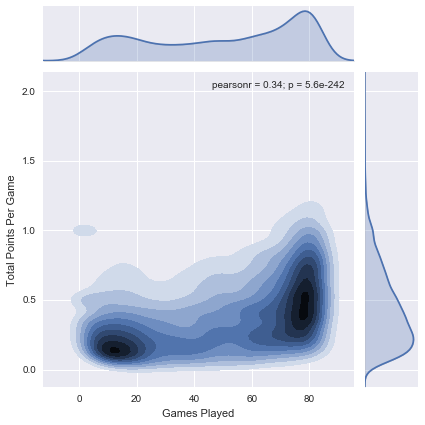

```python
g = sns.jointplot(data=df, x= 'GamesPlayed', y='TotalPointsPerGame', kind="kde")
g.ax_joint.collections[0].set_alpha(0)
g.set_axis_labels("Games Played", "Total Points Per Game");
```

Looks like there are two sets of players. Those that play less than 20 games and those that play over 60 games.

# Analysis

Since there wasn't a clear linear relationship between age and TPPG, another type of analysis must be done. I chose to follow something similar to the fivethirtyeight's CARMELO system. To essentially use the historical data to group players together with t-Distributed Stochastic Neighbor Embedding (t-SNE) and project careers path. The advantage of using t-SNE is to use an unsupervised approach as there was no easy correlation between Age and TPPG. With the hopes that we can infer natural groupings of all NHL players as our best estimate to find out what age Conner McDavid (or any other player) will peak at or what his career will be like.

Process:

1. Compute the correlation matrix for stats for all players.
2. Use PCA or a truncated SVD to reduce data to fewer dimensions. So in the future when more stats and features of the dataset are added, this approach can still be used.
3. Applying the t-SNE dimensionality reduction algorithm. Roughly, t-SNE is considered to be useful because of its property to conserve the overall topology of the data, so that neighboring players are mapped to neighboring locations in a two-dimensional space
4. Visualize and grab players that are closest to Conner McDavid. Calculate how close they were and associate that to a similarity score.
5. Polynomial Regression to estimate Conner McDavid's future stats.

Note: Could use other clustering techniques such as k-means or MDS, but visualization is easily seen with t-SNE. Model will get better with more stats and more data from Conner McDavid.

```python
# Set index
df_final = df
df_final = df_final.set_index(['PlayerId', 'Team', 'Name', 'Age'])
```